# L2-Statistiques et règles de gestion

Thomas FONTAINE, Dan GOLDMAN, Juliette LEMAINS, Nicolas ROBIN

27 janvier 2019

# Projet Transverse - Livrable 2

Pour le projet sur lequel nous devons travailler, nous avons fait le choix de considérer que l’enseigne est une chaîne de magasins de jardinerie.

[figure not shown]

# Statistiques et règles de gestion

## 1 - Livrable attendu

- Fournir les statistiques des différentes tables
- Faire une proposition éventuelle de règles de gestion et de correction des données manquantes et aberrantes.
- Faire une proposition des indicateurs clefs, aux fins de servir la problématique et les règles de construction des indicateurs.

## 2 - Architecture

L’architecture des tables est réparties en 5 tables distinctes :`

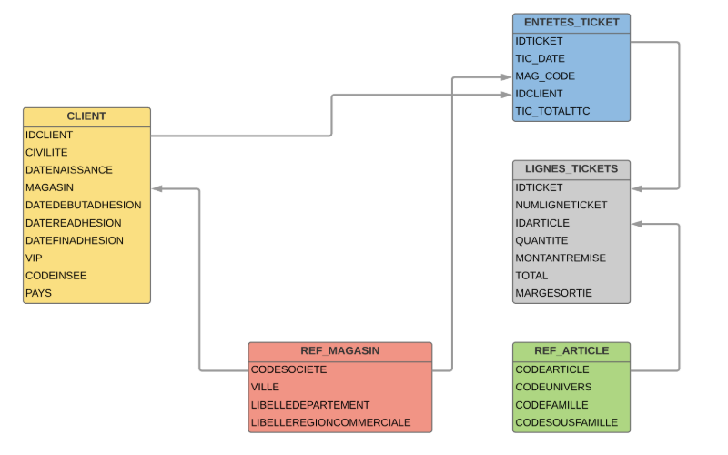

Nous avons dans un premier temps procédé à l’analyse statistique des données pour chacune des tables.

## 3 - Statistiques des différentes tables

## 3.1 - Table Articles

### Structure

| Colonne | Type | Nature.de.la.variable | Valeurs.uniques | TVM |
| --- | --- | --- | --- | --- |
| CODEARTICLE | character | Identifiant | 665946 | 0% |
| CODEUNIVERS | character | Discrete | 6 | 0% |
| CODEFAMILLE | character | Discrete | 26 | 0% |
| CODESOUSFAMILLE | character | Discrete | 344 | 0% |

Note:  
TVM = Taux des Valeurs Manquantes

### Tris à plat

| ModalitÃ.s | Effectifs | Pourcentage |
| --- | --- | --- |
| CODEUNIVERS |  |  |
| COUPON | 1 | 0 |
| U0 | 16016 | 2.4 |
| U1 | 274652 | 41.2 |
| U2 | 236139 | 35.5 |
| U3 | 72725 | 10.9 |
| U4 | 66413 | 10 |
| CODEFAMILLE |  |  |
| 010 | 65324 | 9.8 |
| 020 | 31685 | 4.8 |
| 030 | 22165 | 3.3 |
| 040 | 5176 | 0.8 |
| 050 | 22395 | 3.4 |
| 060 | 979 | 0.1 |
| 070 | 14484 | 2.2 |
| 080 | 36253 | 5.4 |
| 090 | 157747 | 23.7 |
| 100 | 33971 | 5.1 |
| 110 | 11839 | 1.8 |
| 120 | 60886 | 9.1 |
| 130 | 63055 | 9.5 |
| 140 | 33907 | 5.1 |
| 160 | 8561 | 1.3 |
| 170 | 3570 | 0.5 |
| 180 | 46685 | 7 |
| 190 | 6449 | 1 |
| 200 | 1613 | 0.2 |
| 210 | 853 | 0.1 |
| 220 | 30893 | 4.6 |
| 230 | 1092 | 0.2 |
| 400 | 3884 | 0.6 |
| 900 | 2196 | 0.3 |
| 990 | 283 | 0 |
| COUPON | 1 | 0 |

### Statistiques de base

Cette section est vide : la table ne renferme aucune colonne étiquetées avec des variables continues.

### Sortie Console

```
## ----------------------- Table : articles -----------
##
## ------------ CODEARTICLE : -----------
##
## Variable representant un identifiant
##
## ------------ CODEUNIVERS : -----------
##
## Type : character
## Valeurs unique : 6
## Frequence de modalites :
##             n    %
## COUPON      1  0.0
## U0      16016  2.4
## U1     274652 41.2
## U2     236139 35.5
## U3      72725 10.9
## U4      66413 10.0
## Taux de valeurs manquantes : 0 %
##
## ------------ CODEFAMILLE : -----------
##
## Type : character
## Valeurs unique : 26
## Taux de valeurs manquantes : 0 %
##
## ------------ CODESOUSFAMILLE : -----------
##
## Type : character
## Valeurs unique : 344
## Taux de valeurs manquantes : 0 %
```

## 3.2 - Table Magasins

### Structure

| Colonne | Type | Nature.de.la.variable | Valeurs.uniques | TVM |
| --- | --- | --- | --- | --- |
| CODESOCIETE | character | Identifiant | 67 | 0% |
| VILLE | character | Discrete | 67 | 0% |
| LIBELLEDEPARTEMENT | integer | Discrete | 34 | 0% |
| LIBELLEREGIONCOMMERCIALE | character | Discrete | 5 | 0% |

Note:  
TVM = Taux des Valeurs Manquantes

### Tris à plat

| ModalitÃ.s | Effectifs | Pourcentage |
| --- | --- | --- |
| LIBELLEDEPARTEMENT |  |  |
| 1 | 1 | 1.5 |
| 4 | 3 | 4.5 |
| 5 | 1 | 1.5 |
| 6 | 2 | 3 |
| 8 | 2 | 3 |
| 10 | 1 | 1.5 |
| 13 | 4 | 6 |
| 21 | 2 | 3 |
| 26 | 1 | 1.5 |
| 30 | 1 | 1.5 |
| 31 | 2 | 3 |
| 34 | 2 | 3 |
| 38 | 3 | 4.5 |
| 42 | 2 | 3 |
| 45 | 1 | 1.5 |
| 54 | 1 | 1.5 |
| 57 | 1 | 1.5 |
| 58 | 2 | 3 |
| 63 | 1 | 1.5 |
| 66 | 1 | 1.5 |
| 67 | 5 | 7.5 |
| 68 | 1 | 1.5 |
| 69 | 5 | 7.5 |
| 71 | 1 | 1.5 |
| 72 | 1 | 1.5 |
| 73 | 2 | 3 |
| 74 | 8 | 11.9 |
| 77 | 2 | 3 |
| 83 | 2 | 3 |
| 84 | 1 | 1.5 |
| 88 | 1 | 1.5 |
| 89 | 1 | 1.5 |
| 91 | 1 | 1.5 |
| 92 | 2 | 3 |
| LIBELLEREGIONCOMMERCIALE |  |  |
| Alsace-Est | 15 | 22.4 |
| Centre-Paris | 12 | 17.9 |
| Littoral | 19 | 28.4 |
| RhÃ´ne-Alpes | 20 | 29.9 |
| Vente en ligne | 1 | 1.5 |

### Statistiques de base

Cette section est vide : la table ne renferme aucune colonne étiquetées avec des variables continues.

### Sortie Console

```
## ----------------------- Table : magasins -----------
##
## ------------ CODESOCIETE : -----------
##
## Type : character
## Valeurs unique : 67
## Taux de valeurs manquantes : 0 %
##
## ------------ VILLE : -----------
##
## Type : character
## Valeurs unique : 67
## Taux de valeurs manquantes : 0 %
##
## ------------ LIBELLEDEPARTEMENT : -----------
##
## Type : integer
## Valeurs unique : 34
## Minimum :  1 Minimum 1: 4
## Maximum : 92 Maximum 1: 91
## Moyenne : 51
## Median : 66
## Ecart type : 28.4
## Coefficient de variation : 0.6
## Taux de valeurs manquantes : 0 %
##
## ------------ LIBELLEREGIONCOMMERCIALE : -----------
##
## Type : character
## Valeurs unique : 5
## Frequence de modalites :
##                 n    %
## Alsace-Est     15 22.4
## Centre-Paris   12 17.9
## Littoral       19 28.4
## RhÃ´ne-Alpes   20 29.9
## Vente en ligne  1  1.5
## Taux de valeurs manquantes : 0 %
```

## 3.3 - Table Clients

### Structure

| Colonne | Type | Nature.de.la.variable | Valeurs.uniques | TVM |
| --- | --- | --- | --- | --- |
| IDCLIENT | integer | Identifiant | 8464 | 0% |
| CIVILITE | character | Discrete | 6 | 0% |
| DATENAISSANCE | double | Date | 4486 | 39.698% |
| MAGASIN | character | Discrete | 67 | 0% |
| DATEDEBUTADHESION | double | Date | 3415 | 0% |
| DATEREADHESION | double | Date | 1221 | 40.052% |
| DATEFINADHESION | double | Date | 53 | 0% |
| VIP | integer | Discrete | 2 | 0% |
| CODEINSEE | character | Discrete | 2700 | 3.497% |
| PAYS | character | Discrete | 5 | 0% |

Note:  
TVM = Taux des Valeurs Manquantes

### Tris à plat

| ModalitÃ.s | Effectifs | Pourcentage |
| --- | --- | --- |
| CIVILITE |  |  |
| madame | 15 | 0.2 |
| MADAME | 4603 | 54.4 |
| Mme | 14 | 0.2 |
| monsieur | 8 | 0.1 |
| MONSIEUR | 3809 | 45 |
| Mr | 15 | 0.2 |
| VIP |  |  |
| 0 | 7356 | 86.9 |
| 1 | 1108 | 13.1 |
| PAYS |  |  |
| BE | 2 | 0 |
| CH | 210 | 2.5 |
| DE | 1 | 0 |
| FR | 8250 | 97.5 |
| LU | 1 | 0 |

### Statistiques de base

| Colonne | Min | Min1 | Max | Max1 | Mean | Median | Ecart.Type | CV |
| --- | --- | --- | --- | --- | --- | --- | --- | --- |
| DATENAISSANCE | 1868-11-18 | NA | 7973-10-30 | NA | NA | NA | NA | NA |
| DATEDEBUTADHESION | 1998-01-18 | NA | 2017-12-31 | NA | NA | NA | NA | NA |
| DATEREADHESION | 2008-07-02 | NA | 2018-01-07 | NA | NA | NA | NA | NA |
| DATEFINADHESION | 2016-01-31 | NA | 2094-06-30 | NA | NA | NA | NA | NA |

### Sortie Console

```
## ----------------------- Table : clients -----------
##
## ------------ IDCLIENT : -----------
##
## Variable representant un identifiant
##
## ------------ CIVILITE : -----------
##
## Type : character
## Valeurs unique : 6
## Frequence de modalites :
##             n    %
## madame     15  0.2
## MADAME   4603 54.4
## Mme        14  0.2
## monsieur    8  0.1
## MONSIEUR 3809 45.0
## Mr         15  0.2
## Taux de valeurs manquantes : 0 %
##
## ------------ DATENAISSANCE : -----------
##
## Type : Date
## Minimum : 1868-11-18 Maximum : 7973-10-30
## Taux de valeurs manquantes : 39.69754 %
##
## ------------ MAGASIN : -----------
##
## Type : character
## Valeurs unique : 67
## Taux de valeurs manquantes : 0 %
##
## ------------ DATEDEBUTADHESION : -----------
##
## Type : Date
## Minimum : 1998-01-18 Maximum : 2017-12-31
## Taux de valeurs manquantes : 0 %
##
## ------------ DATEREADHESION : -----------
##
```

[output cut: 23 more lines]

```
##
## Variable representant un identifiant
##
## ------------ PAYS : -----------
##
## Type : character
## Valeurs unique : 5
## Frequence de modalites :
##       n    %
## BE    2  0.0
## CH  210  2.5
## DE    1  0.0
## FR 8250 97.5
## LU    1  0.0
## Taux de valeurs manquantes : 0 %
```

## 3.4 - Table Entêtes

### Structure

| Colonne | Type | Nature.de.la.variable | Valeurs.uniques | TVM |
| --- | --- | --- | --- | --- |
| IDTICKET | double | Identifiant | 67129 | 0% |
| TIC_DATE | character | Date | 67004 | 0% |
| MAG_CODE | character | Discrete | 66 | 0% |
| IDCLIENT | double | Identifiant | 60108 | 0% |
| TIC_TOTALTTC | double | Continue | 16136 | 0% |

Note:  
TVM = Taux des Valeurs Manquantes

### Statistiques de base

| Colonne | Min | Min1 | Max | Max1 | Mean | Median | Ecart.Type | CV |
| --- | --- | --- | --- | --- | --- | --- | --- | --- |
| TIC_DATE | 2016-01-02 09:50:50 | NA | 2017-12-31 18:03:26 | NA | NA | NA | NA | NA |
| TIC_TOTALTTC | -1907.90 | -1907.9 | 3397.43 | 3364.32 | 58.472 | 37.7 | 88.214 | 1.509 |

### Sortie Console

```
## ----------------------- Table : entetes -----------
##
## ------------ IDTICKET : -----------
##
## Variable representant un identifiant
##
## ------------ TIC_DATE : -----------
##
## Type : Date
## Minimum : 2016-01-02 09:50:50 Maximum : 2017-12-31 18:03:26
## Taux de valeurs manquantes : 0 %
##
## ------------ MAG_CODE : -----------
##
## Type : character
## Valeurs unique : 66
## Taux de valeurs manquantes : 0 %
##
## ------------ IDCLIENT : -----------
##
## Variable representant un identifiant
##
## ------------ TIC_TOTALTTC : -----------
##
## Type : double
## Valeurs unique : 16136
## Minimum : -1907.90 Minimum 1: -1907.9
## Maximum :  3397.43 Maximum 1: 3364.32
## Moyenne : 58.5
## Median : 37.7
## Ecart type : 88.2
## Coefficient de variation : 1.5
## Taux de valeurs manquantes : 0 %
```

## 3.5 - Table Lignes

### Structure

| Colonne | Type | Nature.de.la.variable | Valeurs.uniques | TVM |
| --- | --- | --- | --- | --- |
| IDTICKET | double | Identifiant | 326361 | 0% |
| NUMLIGNETICKET | integer | Discrete | 92 | 0% |
| IDARTICLE | character | Identifiant | 49274 | 0% |
| QUANTITE | double | Continue | 2485 | 0% |
| MONTANTREMISE | double | Continue | 3693 | 0% |
| TOTAL | double | Continue | 6821 | 0% |
| MARGESORTIE | double | Continue | 6986 | 0% |

Note:  
TVM = Taux des Valeurs Manquantes

### Statistiques de base

| Colonne | Min | Min1 | Max | Max1 | Mean | Median | Ecart.Type | CV |
| --- | --- | --- | --- | --- | --- | --- | --- | --- |
| QUANTITE | -10.000 | -20 | 188.000 | 170 | 1.331 | 1 | 2.208 | 1.659 |
| MONTANTREMISE | -14.000 | -1.667 | 1466.667 | 707.242 | 0.98 | 0 | 5.754 | 5.871 |
| TOTAL | -1203.46 | -1203.46 | 1979.25 | 1762.5 | 9.951 | 5.21 | 23.541 | 2.366 |
| MARGESORTIE | -1827.50 | -720.99 | 958.33 | 833.33 | 4.234 | 2.27 | 10.564 | 2.495 |

### Sortie Console

```
## ----------------------- Table : lignes -----------
##
## ------------ IDTICKET : -----------
##
## Variable representant un identifiant
##
## ------------ NUMLIGNETICKET : -----------
##
## Type : integer
## Valeurs unique : 92
## Minimum :   1 Minimum 1: 2
## Maximum : 114 Maximum 1: 106
## Moyenne : 5.6
## Median : 4
## Ecart type : 5.8
## Coefficient de variation : 1
## Taux de valeurs manquantes : 0 %
##
## ------------ IDARTICLE : -----------
##
## Variable representant un identifiant
##
## ------------ QUANTITE : -----------
##
## Type : double
## Valeurs unique : 2485
## Minimum : -10.000 Minimum 1: -20
## Maximum : 188.000 Maximum 1: 170
## Moyenne : 1.3
## Median : 1
## Ecart type : 2.2
## Coefficient de variation : 1.7
## Taux de valeurs manquantes : 0 %
##
## ------------ MONTANTREMISE : -----------
##
## Type : double
## Valeurs unique : 3693
## Minimum :  -14.000 Minimum 1: -1.667
## Maximum : 1466.667 Maximum 1: 707.242
```

[output cut: 14 more lines]

```
## Ecart type : 23.5
## Coefficient de variation : 2.4
## Taux de valeurs manquantes : 0 %
##
## ------------ MARGESORTIE : -----------
##
## Type : double
## Valeurs unique : 6986
## Minimum : -1827.50 Minimum 1: -720.99
## Maximum :   958.33 Maximum 1: 833.33
## Moyenne : 4.2
## Median : 2.27
## Ecart type : 10.6
## Coefficient de variation : 2.5
## Taux de valeurs manquantes : 0 %
```